# Cheddar Faraway

### 1. Introducción

Tenenemos un conjunto de datos en el que se recogen observaciones de una cata de quesos, nuestras variables son:

**· Taste:** una valoración subjetiva de los jueces.

**· Acetic:** la concentración de ácido acético en un queso de terminado en esca la logarítmica

**· H2S:** la concentración de sulfito de hidrógeno en escala logarítmica.

**· Lactic:** Concentración de ácido láctico

```r
library(faraway)
data(cheddar)
head(cheddar)
```

|  | taste | Acetic | H2S | Lactic |
| --- | --- | --- | --- | --- |
| 1 | 12.3 | 4.543 | 3.135 | 0.86 |
| 2 | 20.9 | 5.159 | 5.043 | 1.53 |
| 3 | 39.0 | 5.366 | 5.438 | 1.57 |
| 4 | 47.9 | 5.759 | 7.496 | 1.81 |
| 5 | 5.6 | 4.663 | 3.807 | 0.99 |
| 6 | 25.9 | 5.697 | 7.601 | 1.09 |

```r
sapply(cheddar, class)
```

```
    taste    Acetic       H2S    Lactic
"numeric" "numeric" "numeric" "numeric"
```

Al ser todas numéricas no hay que hacer encoding a variables binarias

Usamos el número de observaciones para determinar los conjuntos de train y test

```r
numObs <- dim(cheddar)[1]
numObs
```

```
[1] 30
```

```r
# Para asegurar que sea reproducible

set.seed(101)
sample <- sample.int(n = nrow(cheddar),
                     size = floor(.7 * nrow(cheddar)),
                     replace = F)
train <- cheddar[sample, ]
test <- cheddar[-sample, ]
```

### 2.Estudio y evaluación del modelo completo.

Simplificamos nuestra notación para las variables, la que intentaremos predecir es taste.

```r
T <- cheddar$taste
A <- cheddar$Acetic
H <- cheddar$H2S
L <- cheddar$Lactic
```

Definimos nuestro modelo completo:

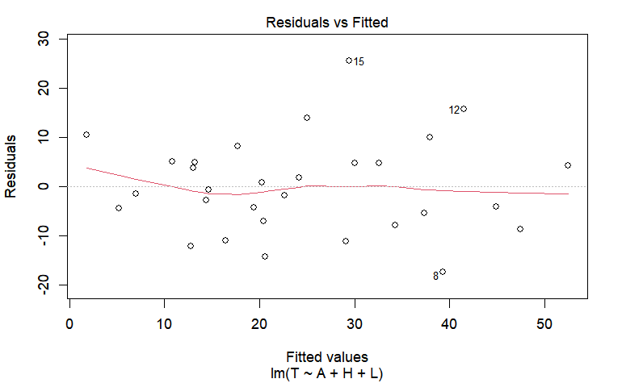

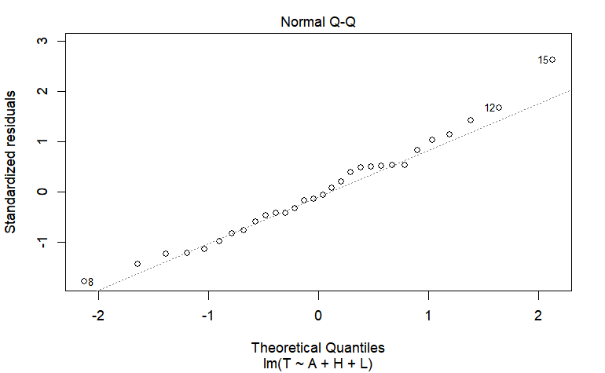

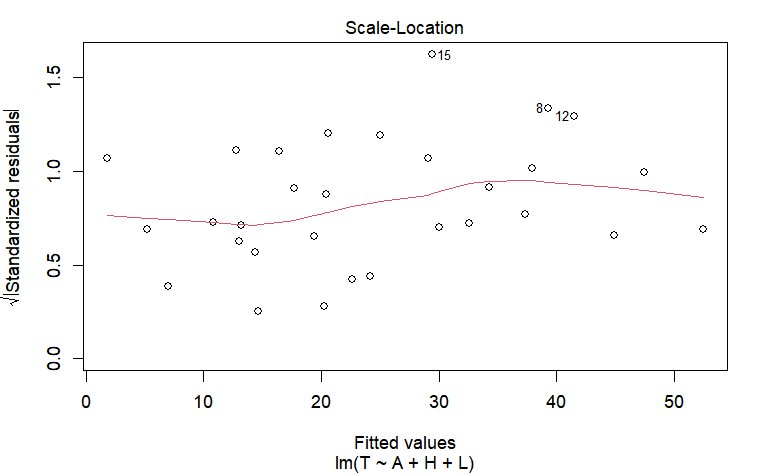

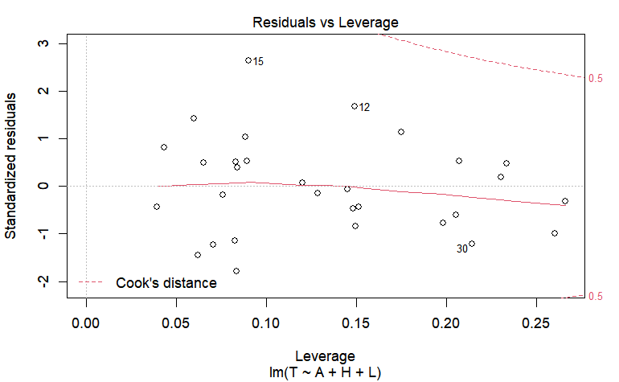

```r
model.completo.lm <- lm(T~A+H+L, data=train)
plot(model.completo.lm)
```

```r
cor(train)
```

```
           taste    Acetic       H2S    Lactic
taste  1.0000000 0.4944292 0.7769666 0.7598731
Acetic 0.4944292 1.0000000 0.5844270 0.7243627
H2S    0.7769666 0.5844270 1.0000000 0.6776785
Lactic 0.7598731 0.7243627 0.6776785 1.0000000
```

```r
shapiro.test(resid(model.completo.lm))
```

```
    Shapiro-Wilk normality test

data:  resid(model.completo.lm)
W = 0.98021, p-value = 0.8312
```

Observamos que estamos en la hipótesis de que el error nuestro modelo se distribuye de manera normal.

¿Tienen todas las variables un impacto relevante en el modelo?

```r
summary(model.completo.lm)
```

```
Call:
lm(formula = T ~ A + H + L, data = train)

Residuals:
    Min      1Q  Median      3Q     Max
-17.390  -6.612  -1.009   4.908  25.449

Coefficients:
            Estimate Std. Error t value Pr(>|t|)
(Intercept) -28.8768    19.7354  -1.463  0.15540
A             0.3277     4.4598   0.073  0.94198
H             3.9118     1.2484   3.133  0.00425 **
L            19.6705     8.6291   2.280  0.03108 *
---
Signif. codes:  0 ‘***’ 0.001 ‘**’ 0.01 ‘*’ 0.05 ‘.’ 0.1 ‘ ’ 1

Residual standard error: 10.13 on 26 degrees of freedom
Multiple R-squared:  0.6518,    Adjusted R-squared:  0.6116
F-statistic: 16.22 on 3 and 26 DF,  p-value: 3.81e-06
```

```r
betahat<- matrix(coef(model.completo.lm),ncol=1)
```

Obervamos el p-valor de A nos indica que con casi toda seguridad A no tiene impacto real en el modelo ( > 0.94)

```r
anova(model.completo.lm)
```

```
Analysis of Variance Table

Response: T
          Df  Sum Sq Mean Sq F value    Pr(>F)
A          1 2314.14 2314.14 22.5481 6.528e-05 ***
H          1 2147.02 2147.02 20.9197 0.0001035 ***
L          1  533.32  533.32  5.1964 0.0310795 *
Residuals 26 2668.41  102.63
---
Signif. codes:  0 ‘***’ 0.001 ‘**’ 0.01 ‘*’ 0.05 ‘.’ 0.1 ‘ ’ 1
```

Una vez hemos concluido que aunque estamos en las hipótesis de regresión lineal el modelo completo a pesar de ser el más complejo probablemente da resultados similares a otro más simple.

### 3.¿Cuál es el mejor modelo?

#### 3.1. Método Backward

Partimos del modelo completo estudiado en la sección anterior y aplicamos con = 0.05.

```r
drop1(model.completo.lm, test = "F")
```

```
Single term deletions

Model:
T ~ A + H + L
       Df Sum of Sq    RSS    AIC F value   Pr(>F)
<none>              2668.4 142.64
A       1      0.55 2669.0 140.65  0.0054 0.941980
H       1   1007.66 3676.1 150.25  9.8182 0.004247 **
L       1    533.32 3201.7 146.11  5.1964 0.031079 *
---
Signif. codes:  0 ‘***’ 0.001 ‘**’ 0.01 ‘*’ 0.05 ‘.’ 0.1 ‘ ’ 1
```

Quitamos Acetic del modelo debido que su p-valor es > 0.05

```r
model.update1 <- update(model.completo.lm, . ~ . - A)
drop1(model.update1, test = "F")
```

```
Single term deletions

Model:
T ~ H + L
       Df Sum of Sq    RSS    AIC F value   Pr(>F)
<none>              2669.0 140.65
H       1   1193.52 3862.5 149.74 12.0740 0.001743 **
L       1    617.18 3286.1 144.89  6.2435 0.018850 *
---
Signif. codes:  0 ‘***’ 0.001 ‘**’ 0.01 ‘*’ 0.05 ‘.’ 0.1 ‘ ’ 1
```

Todos los p-valores son menores que = 0.05 por lo tanto hemos concluido

```r
model.backward.lm <- lm(T~H+L, data = train)
summary(model.backward.lm)
```

```
Call:
lm(formula = T ~ H + L, data = train)

Residuals:
    Min      1Q  Median      3Q     Max
-17.343  -6.530  -1.164   4.844  25.618

Coefficients:
            Estimate Std. Error t value Pr(>|t|)
(Intercept)  -27.592      8.982  -3.072  0.00481 **
H              3.946      1.136   3.475  0.00174 **
L             19.887      7.959   2.499  0.01885 *
---
Signif. codes:  0 ‘***’ 0.001 ‘**’ 0.01 ‘*’ 0.05 ‘.’ 0.1 ‘ ’ 1

Residual standard error: 9.942 on 27 degrees of freedom
Multiple R-squared:  0.6517,    Adjusted R-squared:  0.6259
F-statistic: 25.26 on 2 and 27 DF,  p-value: 6.551e-07
```

```r
SCOPE<-(~.+A + H + L)
model.inicial <- lm(T~1,data=train)
add1(model.inicial,scope=SCOPE,test="F")
```

```
Single term additions

Model:
T ~ 1
       Df Sum of Sq    RSS    AIC F value    Pr(>F)
<none>              7662.9 168.29
A       1    2314.1 5348.7 159.50  12.114  0.001658 **
H       1    4376.7 3286.1 144.89  37.293 1.374e-06 ***
L       1    3800.4 3862.5 149.74  27.550 1.405e-05 ***
---
Signif. codes:  0 ‘***’ 0.001 ‘**’ 0.01 ‘*’ 0.05 ‘.’ 0.1 ‘ ’ 1
```

Actualizamos añadiendo el de menor pvalue

```r
model.updatei1 <- update(model.inicial, .~. +H)
add1(model.updatei1,scope=SCOPE,test="F")
```

```
Single term additions

Model:
T ~ H
       Df Sum of Sq    RSS    AIC F value  Pr(>F)
<none>              3286.1 144.89
A       1     84.41 3201.7 146.11  0.7118 0.40625
L       1    617.18 2669.0 140.65  6.2435 0.01885 *
---
Signif. codes:  0 ‘***’ 0.001 ‘**’ 0.01 ‘*’ 0.05 ‘.’ 0.1 ‘ ’ 1
```

```r
model.updatei2<-update(model.updatei1, .~. +L)
add1(model.updatei2,scope=SCOPE,test="F")
```

```
Single term additions

Model:
T ~ H + L
       Df Sum of Sq    RSS    AIC F value Pr(>F)
<none>              2669.0 140.65
A       1   0.55427 2668.4 142.64  0.0054  0.942
```

Ahora es el modelo final, igual vale con alpha de minimo 0.02

```r
model.forward.lm<-lm(T~H+L, data=train)
summary(model.forward.lm)
```

```
Call:
lm(formula = T ~ H + L, data = train)

Residuals:
    Min      1Q  Median      3Q     Max
-17.343  -6.530  -1.164   4.844  25.618

Coefficients:
            Estimate Std. Error t value Pr(>|t|)
(Intercept)  -27.592      8.982  -3.072  0.00481 **
H              3.946      1.136   3.475  0.00174 **
L             19.887      7.959   2.499  0.01885 *
---
Signif. codes:  0 ‘***’ 0.001 ‘**’ 0.01 ‘*’ 0.05 ‘.’ 0.1 ‘ ’ 1

Residual standard error: 9.942 on 27 degrees of freedom
Multiple R-squared:  0.6517,    Adjusted R-squared:  0.6259
F-statistic: 25.26 on 2 and 27 DF,  p-value: 6.551e-07
```

#### 3.3.Construcción por criterios

Necesitaremos la librería leaps para esta subsección.

```r
library(leaps)
```

```r
models<-regsubsets(taste~., data=train)
summary(models)
```

```
Subset selection object
Call: regsubsets.formula(taste ~ ., data = train)
3 Variables  (and intercept)
       Forced in Forced out
Acetic     FALSE      FALSE
H2S        FALSE      FALSE
Lactic     FALSE      FALSE
1 subsets of each size up to 3
Selection Algorithm: exhaustive
         Acetic H2S Lactic
1  ( 1 ) " "    "*" " "
2  ( 1 ) " "    "*" "*"
3  ( 1 ) "*"    "*" "*"
```

```r
MR2adj<-summary(models)$adjr2
MR2adj
```

```
[1] 0.5828180 0.6715170 0.6784998
```

```r
which.max(MR2adj)
```

```
[1] 3
```

```r
summary(models)$which[2, ]
```

```
(Intercept)      Acetic         H2S      Lactic
       TRUE       FALSE        TRUE        TRUE
```

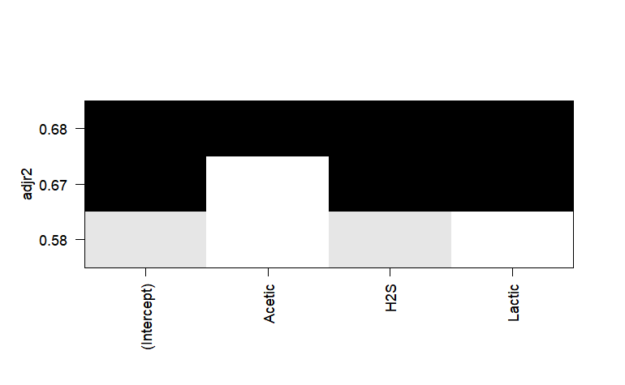

```r
model.final3<-lm(taste~H2S+Lactic, data=train)
plot(models,scale="adjr2")
```

Se busca el máximo y se ve como crece

```r
MCp <-summary(models)$cp
which.min(MCp)
```

```
[1] 2
```

```r
summary(models)$which[2, ]
```

```
(Intercept)      Acetic         H2S      Lactic
       TRUE       FALSE        TRUE        TRUE
```

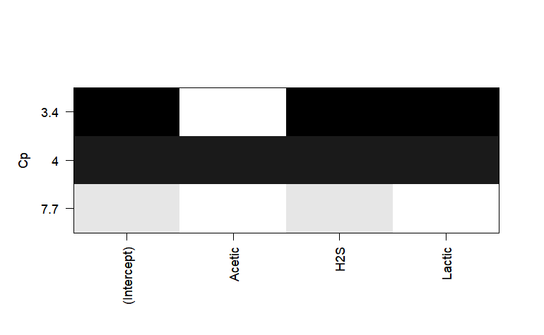

```r
model.final4<-lm(taste~H2S+Lactic, data=train)
plot(models,scale="Cp")
```

Se busca el minimo y se ve como decrece

```r
MBIC <-summary(models)$bic
which.min(MBIC)
```

```
[1] 2
```

```r
summary(models)$which[2, ]
```

```
(Intercept)      Acetic         H2S      Lactic
       TRUE       FALSE        TRUE        TRUE
```

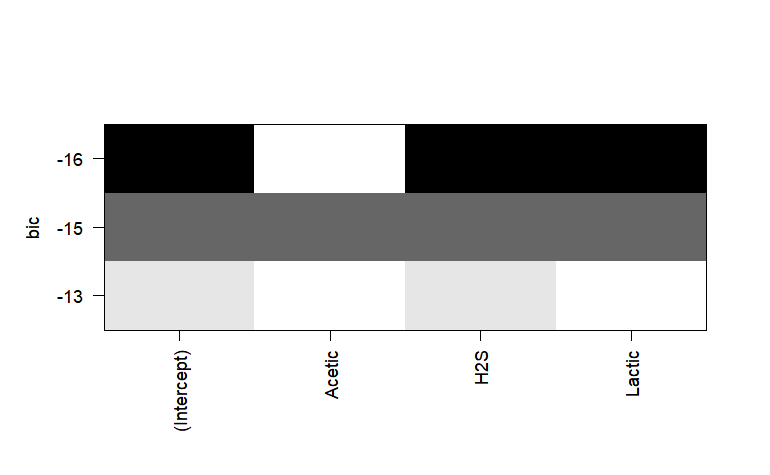

```r
model.final5<-lm(taste~H2S+Lactic, data=train)
plot(models,scale="bic")
```

```r
library(MASS)
model.completo.lm <- lm(taste~., data=train)
SCOPE <-(~.)
stepAIC(model.completo.lm, scope=SCOPE, k=2)
```

```
Start:  AIC=94.42
taste ~ Acetic + H2S + Lactic

         Df Sum of Sq    RSS     AIC
- Acetic  1    105.29 1392.2  94.076
<none>                1286.9  94.424
- Lactic  1    567.80 1854.7 100.100
- H2S     1    672.09 1959.0 101.249

Step:  AIC=94.08
taste ~ H2S + Lactic

         Df Sum of Sq    RSS    AIC
<none>                1392.2 94.076
+ Acetic  1    105.29 1286.9 94.424
- Lactic  1    474.15 1866.3 98.231
- H2S     1    597.86 1990.0 99.579

Call:
lm(formula = taste ~ H2S + Lactic, data = train)

Coefficients:
(Intercept)          H2S       Lactic
    -28.263        3.536       21.965
```